# Tugas Praktikum 2 MPDW

Sofia Lorena

2025-09-02

# Tahap 1: Persiapan Data

```r
library(TTR)
library(forecast)
library(lmtest) #digunakan untuk uji formal pendeteksian autokorelasi
library(orcutt) #untuk membuat model regresi Cochrane-Orcutt
library(HoRM) #untuk membuat model regresi Hildreth-Lu
library(readxl)
dt_IPM <- read_excel("C:\\Users\\LENOVO\\Downloads\\data mpdw.xlsx")
dt_IPM
```

```
## # A tibble: 14 × 2
##    Tahun   IPM
##    <dbl> <dbl>
##  1  2011  66.0
##  2  2012  66.6
##  3  2013  67.5
##  4  2014  68.1
##  5  2015  68.6
##  6  2016  69.3
##  7  2017  70.0
##  8  2018  70.6
##  9  2019  71.2
## 10  2020  71.4
## 11  2021  71.6
## 12  2022  72.2
## 13  2023  72.8
## 14  2024  73.4
```

# Tahap 2: Membuat Model Awal

```r
# Membuat model regresi OLS (Ordinary Least Squares)
model_awal <- lm(IPM ~ Tahun, data = dt_IPM)
summary(model_awal)
```

```
##
## Call:
## lm(formula = IPM ~ Tahun, data = dt_IPM)
##
## Residuals:
##      Min       1Q   Median       3Q      Max
## -0.38657 -0.23326  0.03795  0.17996  0.43547
##
## Coefficients:
##               Estimate Std. Error t value Pr(>|t|)
## (Intercept) -1.047e+03  3.737e+01  -28.01 2.66e-12 ***
## Tahun        5.535e-01  1.852e-02   29.88 1.23e-12 ***
## ---
## Signif. codes:  0 '***' 0.001 '**' 0.01 '*' 0.05 '.' 0.1 ' ' 1
##
## Residual standard error: 0.2794 on 12 degrees of freedom
## Multiple R-squared:  0.9867, Adjusted R-squared:  0.9856
## F-statistic: 892.9 on 1 and 12 DF,  p-value: 1.234e-12
```

**Observasi Awal:**

Lihat! **Nilai Adjusted R-squared sangat tinggi (0.9856)** dan koefisien `tahun` **sangat signifikan (p-value < 0.001)**. Model sudah bagus, namun pastikan kembali apakah model memang benar-benar bagus.

# Tahap 3: Diagnosis

## 3.1. Diagnosis Visual

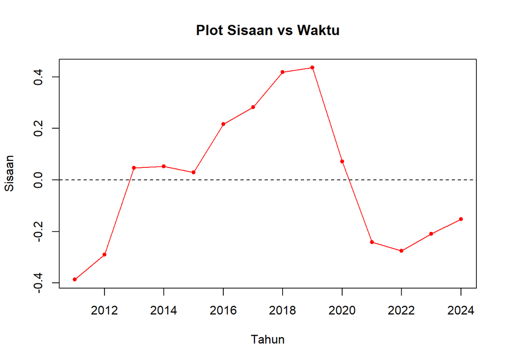

```r
# Ambil sisaan dari model
sisaan_awal <- residuals(model_awal)

# Plot sisaan terhadap waktu
plot(dt_IPM$Tahun, sisaan_awal, type="o", pch=20, col="red",
     main="Plot Sisaan vs Waktu", xlab="Tahun", ylab="Sisaan")
abline(h=0, lty=2) # Garis referensi di y=0
```

**Kecurigaan:**

Plot di atas menunjukkan pola yang **tidak acak**.Sisaan cenderung berkelompok di mana terlihat ada pola naik dan turun. Ini adalah gejala visual yang kuat dari autokorelasi positif. Sisaan positif cenderung diikuti sisaan positif, dan sebaliknya.

## 3.2. Diagnosis Formal (Uji Durbin-Watson)

```r
dwtest(model_awal)
```

```
##
##  Durbin-Watson test
##
## data:  model_awal
## DW = 0.4488, p-value = 8.39e-06
## alternative hypothesis: true autocorrelation is greater than 0
```

**Hasil Investigasi:**

- P-value yang dihasilkan **sangat kecil (8.39e-06)**, yaitu di bawah tingkat signifikansi 0.05.
- Kesimpulan: Kita **menolak H0**. Bukti sudah kuat. Model kita **terbukti menderita autokorelasi**.

# Tahap 4: Penanganan

## 1. Metode Cochrane-Orcutt

```r
model_co <- cochrane.orcutt(model_awal)
summary(model_co)
```

```
## Call:
## lm(formula = IPM ~ Tahun, data = dt_IPM)
##
##                Estimate  Std. Error t value  Pr(>|t|)
## (Intercept) -909.280249   83.142000 -10.936 3.001e-07 ***
## Tahun          0.485506    0.041148  11.799 1.384e-07 ***
## ---
## Signif. codes:  0 '***' 0.001 '**' 0.01 '*' 0.05 '.' 0.1 ' ' 1
##
## Residual standard error: 0.1557 on 11 degrees of freedom
## Multiple R-squared:  0.9268 ,  Adjusted R-squared:  0.9201
## F-statistic: 139.2 on 1 and 11 DF,  p-value: < 1.384e-07
##
## Durbin-Watson statistic
## (original):    0.44880 , p-value: 8.39e-06
## (transformed): 1.43043 , p-value: 7.289e-02
```

```r
# rho paling optimum
rho <- model_co$rho
cat("Rho optimum:", rho)
```

```
## Rho optimum: 0.7194494
```

**Hasil Penanganan (C-O):**

- Statistik **Durbin-Watson baru**. Nilainya sekarang jauh lebih dekat ke 2, dan p-value-nya (> 0.05) menunjukkan bahwa **autokorelasi sudah berhasil diatasi**.
- Perhatikan koefisien `(Intercept)` dan `tahun` yang baru. Ini adalah estimasi yang lebih valid.

**Verifikasi Manual:**

```r
ipm.trans <- dt_IPM$IPM[-1] - dt_IPM$IPM[-14]*rho

tahun.trans <- dt_IPM$Tahun[-1] - dt_IPM$Tahun[-14]*rho
model_co_manual <- lm(ipm.trans~tahun.trans)

b0_co_manual <- coef(model_co_manual)[1]/(1-rho)
b1_co_manual <- coef(model_co_manual)[2]
cat("Koefisien manual Cochrane-Orcutt:\n")
```

```
## Koefisien manual Cochrane-Orcutt:
```

```r
cat("b0:", b0_co_manual, "\n")
```

```
## b0: -909.2802
```

```r
cat("b1:", b1_co_manual, "\n")
```

```
## b1: 0.4855063
```

Hasil koefisien manual sangat mirip dengan hasil dari fungsi otomatis.

## 2. Metode Hildreth-Lu

```r
#Penanganan Autokorelasi Hildreth lu
# Hildreth-Lu
hildreth.lu.func<- function(r, model){
  x <- model.matrix(model)[,-1]
  y <- model.response(model.frame(model))
  n <- length(y)
  t <- 2:n
  y <- y[t]-r*y[t-1]
  x <- x[t]-r*x[t-1]

  return(lm(y~x))
}

#Pencariab rho yang meminimumkan SSE
r <- c(seq(0.1,0.9, by= 0.1))
tab <- data.frame("rho" = r, "SSE" = sapply(r, function(i){deviance(hildreth.lu.func(i, model_awal))}))
round(tab, 4)
```

```
##   rho    SSE
## 1 0.1 0.6143
## 2 0.2 0.5112
## 3 0.3 0.4261
## 4 0.4 0.3592
## 5 0.5 0.3104
## 6 0.6 0.2797
## 7 0.7 0.2671
## 8 0.8 0.2727
## 9 0.9 0.2963
```

```r
#Rho optimal di sekitar 0.7
rOpt <- seq(0.6,0.8, by= 0.001)
tabOpt <- data.frame("rho" = rOpt, "SSE" = sapply(rOpt, function(i){deviance(hildreth.lu.func(i, model_awal))}))
head(tabOpt[order(tabOpt$SSE),])
```

```
##       rho       SSE
## 120 0.719 0.2667970
## 121 0.720 0.2667971
## 119 0.718 0.2667987
## 122 0.721 0.2667990
## 118 0.717 0.2668022
## 123 0.722 0.2668027
```

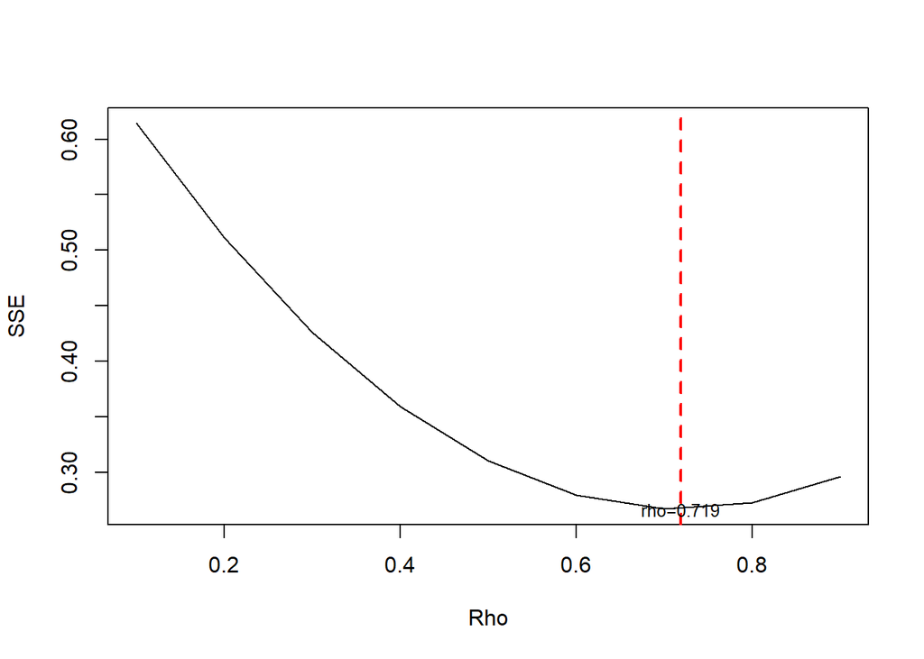

```r
#Grafik SSE optimum
par(mfrow = c(1,1))
plot(tab$SSE ~ tab$rho , type = "l", xlab = "Rho", ylab = "SSE")
abline(v = tabOpt[tabOpt$SSE==min(tabOpt$SSE),"rho"], lty = 2, col="red",lwd=2)
text(x=0.719, y=0.2667970, labels = "rho=0.719", cex = 0.8)
```

```r
model_hl <- hildreth.lu(dt_IPM$IPM, dt_IPM$Tahun, rho = 0.719)
summary(model_hl)
```

```
##
## Call:
## lm(formula = y ~ x)
##
## Residuals:
##      Min       1Q   Median       3Q      Max
## -0.25738 -0.08716  0.06326  0.13198  0.19455
##
## Coefficients:
##               Estimate Std. Error t value Pr(>|t|)
## (Intercept) -255.57493   23.32548  -10.96 2.95e-07 ***
## x              0.48562    0.04108   11.82 1.36e-07 ***
## ---
## Signif. codes:  0 '***' 0.001 '**' 0.01 '*' 0.05 '.' 0.1 ' ' 1
##
## Residual standard error: 0.1557 on 11 degrees of freedom
## Multiple R-squared:  0.927,  Adjusted R-squared:  0.9204
## F-statistic: 139.7 on 1 and 11 DF,  p-value: 1.358e-07
```

```r
#Transformasi Balik
cat("y = ", coef(model_hl)[1]/(1-0.341), "+", coef(model_hl)[2],"x", sep = "")
```

```
## y = -387.8223+0.4856243x
```

```r
#Deteksi autokorelasi
dwtest(model_hl)
```

```
##
##  Durbin-Watson test
##
## data:  model_hl
## DW = 1.43, p-value = 0.07277
## alternative hypothesis: true autocorrelation is greater than 0
```

**Hasil Penanganan (H-L):**

- Plot yang dihasilkan secara visual menunjukkan nilai ρ mana yang memiliki SSE terendah.
- Hasil summary memberikan model akhir yang juga sudah “sehat”, dengan statistik D-W yang sudah membaik.
  - Sebelum transformasi (model_awal) DW = 0.4488, p-value = 8.39e-06. Nilai DW jauh di bawah 2, p-value sangat kecil, ada autokorelasi positif yang signifikan pada residual dan asumsi independensi residual tidak terpenuhi.
  - Sesudah transformasi (model_hl) DW = 1.43, p-value = 0.07277. Nilai DW mendekati 2, p-value > 0.05, tidak ada bukti signifikan adanya autokorelasi positif, dan residual sudah lebih mendekati independen dibanding model awal.

# Tahap 5: Evaluasi Akhir

```r
# Menghitung SSE untuk setiap model secara manual
sse_awal <- sum(residuals(model_awal)^2)
sse_co <- sum(residuals(model_co)^2)
sse_hl <- sum(residuals(model_hl)^2)

# Membuat tabel perbandingan
data.frame(
  Metode = c("Model Awal (Sakit)", "Cochrane-Orcutt (Sehat)", "Hildreth-Lu (Sehat)"),
  SSE = c(sse_awal, sse_co, sse_hl),
  DW_Statistic = c(dwtest(model_awal)$statistic, model_co$DW[3], dwtest(model_hl)$statistic)
)
```

```
##                    Metode       SSE DW_Statistic
## 1      Model Awal (Sakit) 0.9367147    0.4488045
## 2 Cochrane-Orcutt (Sehat) 3.1203037    1.4304293
## 3     Hildreth-Lu (Sehat) 0.2667970    1.4300098
```

**Kesimpulan:**

- Kedua metode berhasil menghilangkan autokorelasi, yang ditunjukkan oleh statistik D-W yang mendekati 2.
- Metode Hildreth-Lu berhasil menurunkan SSE model, namun metode Cochrane-Orcutt justru menaikkan drastis SSE model sehingga akurasi prediksi (fit) menurun drastis.
- Model akhir yang seharusnya kita gunakan adalah Metode Hildreth-Lu karena menghilangkan autokorelasi dan menjaga error tetap rendah.